# Project_Unsupervised_Learning_Clustering_PCA_Final

### Project Description - AllLife Credit Card Customer Segmentation

#### Background

AllLife Bank wants to focus on its credit card customer base in the next financial year. They have been advised by their marketing research team, that the penetration in the market can be improved. Based on this input, the Marketing team proposes to run personalised campaigns to target new customers as well as upsell to existing customers. Another insight from the market research was that the customers perceive the support services of the back poorly. Based on this, the Operations team wants to upgrade the service delivery model, to ensure that customers queries are resolved faster. Head of Marketing and Head of Delivery both decide to reach out to the Data Science team for help.

#### Objective

To identify different segments in the existing customer based on their spending patterns as well as past interaction with the bank.

#### To find

- How many different segments of customers are there?
- How are these segments different from each other?
- What are the recommendations to the bank on how to better market to and service these customers?

#### Data Description

Data is of various customers of a bank with their credit limit, the total number of credit cards the customer has, and different channels through which customer has contacted the bank for any queries, different channels include visiting the bank, online and through a call centre.

#### Data Dictionary

- Sl_No: Serial Number
- Customer Key: Customer Identification Key
- Avg_Credit_Limit: Average Credit Limit for the customer
- Total_Credit_Cards: Number of Credit Cards customer has
- Total_visits_bank: Number of times customer visited the bank
- Total_visits_online: Number of times customer visited the bank website (online)
- Total_calls_made: Number of times customer called bank

#### Importing libraries

```python
import warnings
warnings.filterwarnings("ignore")

import numpy as np
import pandas as pd
import matplotlib.pyplot as plt
%matplotlib inline
import seaborn as sns

from sklearn.preprocessing import StandardScaler
from scipy.spatial.distance import cdist
from scipy.spatial.distance import pdist
from sklearn.cluster import KMeans
from sklearn.metrics import silhouette_score
from yellowbrick.cluster import KElbowVisualizer, SilhouetteVisualizer
from scipy.cluster.hierarchy import dendrogram, linkage,cophenet
from sklearn.cluster import AgglomerativeClustering
from scipy.cluster.hierarchy import fcluster
from sklearn.decomposition import PCA
```

#### Loading data

```python
dataCC = pd.read_excel('Credit Card Customer Data.xlsx')
```

```python
#replacing spaces in column names with underscore (_)
dataCC.columns = dataCC.columns.str.replace(' ','_')
```

```python
#taking a copy of the dataset in case we need original data later on
data = dataCC.copy()
```

#### View first 5 and last 5 rows of the dataset

```python
dataCC.head()
```

|  | Sl_No | Customer_Key | Avg_Credit_Limit | Total_Credit_Cards | Total_visits_bank | Total_visits_online | Total_calls_made |
| --- | --- | --- | --- | --- | --- | --- | --- |
| 0 | 1 | 87073 | 100000 | 2 | 1 | 1 | 0 |
| 1 | 2 | 38414 | 50000 | 3 | 0 | 10 | 9 |
| 2 | 3 | 17341 | 50000 | 7 | 1 | 3 | 4 |
| 3 | 4 | 40496 | 30000 | 5 | 1 | 1 | 4 |
| 4 | 5 | 47437 | 100000 | 6 | 0 | 12 | 3 |

```python
dataCC.tail()
```

|  | Sl_No | Customer_Key | Avg_Credit_Limit | Total_Credit_Cards | Total_visits_bank | Total_visits_online | Total_calls_made |
| --- | --- | --- | --- | --- | --- | --- | --- |
| 655 | 656 | 51108 | 99000 | 10 | 1 | 10 | 0 |
| 656 | 657 | 60732 | 84000 | 10 | 1 | 13 | 2 |
| 657 | 658 | 53834 | 145000 | 8 | 1 | 9 | 1 |
| 658 | 659 | 80655 | 172000 | 10 | 1 | 15 | 0 |
| 659 | 660 | 80150 | 167000 | 9 | 0 | 12 | 2 |

#### Checking shape of dataset

```python
dataCC.shape
```

```
(660, 7)
```

#### Checking data types and number of non-null values for each column

```python
dataCC.info()
```

```
<class 'pandas.core.frame.DataFrame'>
RangeIndex: 660 entries, 0 to 659
Data columns (total 7 columns):
 #   Column               Non-Null Count  Dtype
---  ------               --------------  -----
 0   Sl_No                660 non-null    int64
 1   Customer_Key         660 non-null    int64
 2   Avg_Credit_Limit     660 non-null    int64
 3   Total_Credit_Cards   660 non-null    int64
 4   Total_visits_bank    660 non-null    int64
 5   Total_visits_online  660 non-null    int64
 6   Total_calls_made     660 non-null    int64
dtypes: int64(7)
memory usage: 36.2 KB
```

#### NULL (missing value) check

```python
#Just checking null count, even though we saw there are no nulls from info()
dataCC.isnull().sum().sort_values(ascending=False)
```

```
Total_calls_made       0
Total_visits_online    0
Total_visits_bank      0
Total_Credit_Cards     0
Avg_Credit_Limit       0
Customer_Key           0
Sl_No                  0
dtype: int64
```

- No null or missing values are present in the dataset

#### Number of unique values in each column

```python
dataCC.nunique().sort_values(ascending=False)
```

```
Sl_No                  660
Customer_Key           655
Avg_Credit_Limit       110
Total_visits_online     16
Total_calls_made        11
Total_Credit_Cards      10
Total_visits_bank        6
dtype: int64
```

#### Insights:

- Sl_No is just an ID column, which has a unique(continuous) number for each column and can be dropped (since it has 660 unique values which is equal to the total number of rows in the dataset)
- Customer_Key seem to have only 655 unique values, it is not unique for each customer record, looks like there are duplicate values in the Customer_Key column alone, we should check if these are duplicate rows based on values in other columns too for each customer record
- Avg_Credit_Limit, Total_visits_online, Total_calls_made, Total_Credit_Cards, Total_visits_bank seem to have numeric values and are going to be in the clustering analysis

```python
#Dropping column Sl_No
dataCC.drop('Sl_No',axis=1,inplace=True)
```

```python
#Checking shape again to make sure that Sl_No is dropped
dataCC.shape
```

```
(660, 6)
```

#### Checking for duplicate records in the dataset

```python
#checking duplicate records in the entire dataset
dataCC.duplicated().sum()
```

```
0
```

```python
#checking duplicate records in the column Customer_Key, since unique record count was only 655 and 660 (total row count)
dataCC['Customer_Key'].duplicated().sum()
```

```
5
```

```python
#checking Customer_Key values that have duplicate records in the dataset
dataCC.Customer_Key[dataCC['Customer_Key'].duplicated() == True]
```

```
332    47437
398    96929
432    37252
541    50706
632    97935
Name: Customer_Key, dtype: int64
```

```python
#checking all records for the ablove Customer_Key values
dataCC[dataCC.duplicated('Customer_Key',False)].sort_values(by='Customer_Key')
```

|  | Customer_Key | Avg_Credit_Limit | Total_Credit_Cards | Total_visits_bank | Total_visits_online | Total_calls_made |
| --- | --- | --- | --- | --- | --- | --- |
| 48 | 37252 | 6000 | 4 | 0 | 2 | 8 |
| 432 | 37252 | 59000 | 6 | 2 | 1 | 2 |
| 4 | 47437 | 100000 | 6 | 0 | 12 | 3 |
| 332 | 47437 | 17000 | 7 | 3 | 1 | 0 |
| 411 | 50706 | 44000 | 4 | 5 | 0 | 2 |
| 541 | 50706 | 60000 | 7 | 5 | 2 | 2 |
| 391 | 96929 | 13000 | 4 | 5 | 0 | 0 |
| 398 | 96929 | 67000 | 6 | 2 | 2 | 2 |
| 104 | 97935 | 17000 | 2 | 1 | 2 | 10 |
| 632 | 97935 | 187000 | 7 | 1 | 7 | 0 |

#### Insights:

- Customer_Key column has 5 duplicate values (47437,96929,37252,50706,97935)
- There are 2 records each in the dataset for these 5 Customer_Key values
- But when we see the other columns too, they are having different values for these 5 Customer_Keys
- So this can be thought of as a typo error or data entry error
- We can keep these records and treat them as unique rows (no need to drop these rows)

```python
#Dropping column Customer_Key, since it is just a key and need not be part of clustering
dataCC.drop('Customer_Key',axis=1,inplace=True)
```

```python
#Checking shape again to make sure that Sl_No is dropped
dataCC.shape
```

```
(660, 5)
```

#### Summary of the dataset

```python
#This gives the summary for numeric columns (in this case all 6 columns are numeric)
dataCC.describe().T
```

|  | count | mean | std | min | 25% | 50% | 75% | max |
| --- | --- | --- | --- | --- | --- | --- | --- | --- |
| Avg_Credit_Limit | 660.0 | 34574.242424 | 37625.487804 | 3000.0 | 10000.0 | 18000.0 | 48000.0 | 200000.0 |
| Total_Credit_Cards | 660.0 | 4.706061 | 2.167835 | 1.0 | 3.0 | 5.0 | 6.0 | 10.0 |
| Total_visits_bank | 660.0 | 2.403030 | 1.631813 | 0.0 | 1.0 | 2.0 | 4.0 | 5.0 |
| Total_visits_online | 660.0 | 2.606061 | 2.935724 | 0.0 | 1.0 | 2.0 | 4.0 | 15.0 |
| Total_calls_made | 660.0 | 3.583333 | 2.865317 | 0.0 | 1.0 | 3.0 | 5.0 | 10.0 |

#### Insights:

- Avg_Credit_Limit has a wide range from 3K to 200K, 75% of customers have average credit limit as 48K, mean is higher than median, this shows a high right skewed distribution or possible outliers towards the right end of the data distribution
- Total_Credit_Cards has a range from 1 to 10 and median is 5, shows a normal distribution, mean slightly lower than median though
- Total_visits_bank has a range from 0 to 5, with median 2, mean slightly higher than median, not a big difference, almost normal distribution
- Total_visits_online has a range from 0 to 15 and median is 2, mean is 2.6 which is near to median, but 75% of customers have this value equal to 4, possible outliers towards the right end of the data distribution
- Total_calls_made has a range from 0 to 10, median is 3, mean is 3.58 which is near to median, but 75% of customers have this value equal to 5
- Total_visits_bank,Total_visits_online and Total_calls_made have values '0'

```python
#Checking how many records have Total_visits_bank = 0
(dataCC.Total_visits_bank == 0).sum()
```

```
100
```

- Number of visits to bank can be zero in real world scenarios, so not imputing these values

```python
#Checking how many records have Total_visits_online = 0
(dataCC.Total_visits_online == 0).sum()
```

```
144
```

- Number of times customer visited bank website can be zero in real world scenarios, so not imputing these values

```python
#Checking how many records have Total_calls_made = 0
(dataCC.Total_calls_made == 0).sum()
```

```
97
```

- Number of times customer called bank can also be zero in real world scenarios, so not imputing these values

#### EDA - univariate analysis

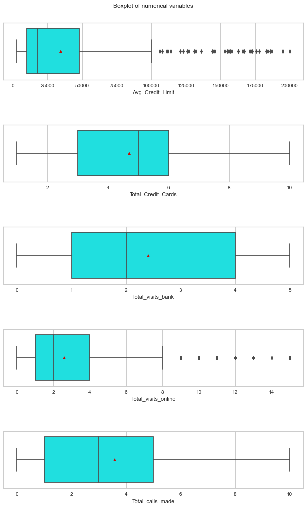

```python
#boxplot for all numerical columns (in this case all variables are numeric)
num_col = dataCC.select_dtypes(include=np.number).columns.tolist()

fig, axes = plt.subplots(5, 1,  figsize=(10, 15))
fig.suptitle('Boxplot of numerical variables', fontsize=12)
counter = 0
for i in range(5):
    sns.boxplot(ax=axes[i],x=dataCC[num_col[counter]],showmeans=True, color='cyan')
    counter = counter+1

fig.tight_layout(pad=5.0)
```

#### Insights:

- Avg_Credit_Limit : We already saw in data summary that, mean is higher than median, 75% for this feature is at 48K and the max is 200K, which shows possible outliers. Boxplot clearly shows outliers towards the right end of data between 100K and 200K.There is a wide range of data from 3K to 200K, we can look at the outliers more.
- Total_Credit_Cards: Mean and median are somewhat close, no outliers in the data distribution
- Total_visits_bank: No outliers, mean slightly higher than median
- Total_visits_online: 75% is at 4, not many customers are using online method to access bank, outliers between 8 and 15
- Total_calls_made: No outliers, mean slightly higher than median, 75% is somewhere around 5, not many customers are using phone calls as a method of communication

#### Checking outliers

```python
#Let us check outliers in Avg_Credit_Limit, boxplot shows outliers
dataCC[dataCC.Avg_Credit_Limit > 100000].sort_values(by='Avg_Credit_Limit')
```

|  | Avg_Credit_Limit | Total_Credit_Cards | Total_visits_bank | Total_visits_online | Total_calls_made |
| --- | --- | --- | --- | --- | --- |
| 634 | 106000 | 8 | 0 | 8 | 1 |
| 620 | 108000 | 10 | 0 | 15 | 1 |
| 648 | 111000 | 8 | 1 | 7 | 0 |
| 649 | 112000 | 10 | 1 | 8 | 1 |
| 635 | 114000 | 10 | 1 | 7 | 2 |
| 618 | 121000 | 7 | 0 | 13 | 2 |
| 640 | 123000 | 8 | 1 | 15 | 2 |
| 636 | 126000 | 10 | 1 | 8 | 0 |
| 644 | 127000 | 10 | 1 | 15 | 1 |
| 615 | 131000 | 9 | 1 | 10 | 1 |
| 651 | 132000 | 9 | 1 | 12 | 2 |
| 617 | 136000 | 8 | 0 | 13 | 0 |
| 641 | 144000 | 10 | 0 | 10 | 2 |
| 657 | 145000 | 8 | 1 | 9 | 1 |
| 627 | 146000 | 10 | 0 | 12 | 1 |
| 638 | 153000 | 8 | 1 | 7 | 1 |
| 629 | 155000 | 8 | 0 | 7 | 2 |
| 652 | 156000 | 8 | 1 | 8 | 0 |
| 626 | 156000 | 9 | 1 | 10 | 2 |
| 612 | 157000 | 9 | 1 | 14 | 1 |
| 619 | 158000 | 7 | 0 | 13 | 0 |
| 633 | 163000 | 7 | 1 | 10 | 1 |
| 614 | 163000 | 8 | 1 | 7 | 1 |
| 621 | 166000 | 9 | 1 | 12 | 2 |
| 623 | 166000 | 10 | 0 | 7 | 0 |
| 659 | 167000 | 9 | 0 | 12 | 2 |
| 645 | 171000 | 10 | 0 | 15 | 0 |
| 658 | 172000 | 10 | 1 | 15 | 0 |
| 654 | 172000 | 10 | 1 | 9 | 1 |
| 637 | 173000 | 9 | 1 | 11 | 0 |
| 622 | 176000 | 10 | 1 | 15 | 2 |
| 624 | 178000 | 7 | 0 | 11 | 0 |
| 647 | 183000 | 9 | 0 | 9 | 2 |
| 639 | 184000 | 7 | 1 | 15 | 2 |
| 646 | 186000 | 7 | 0 | 8 | 1 |
| 632 | 187000 | 7 | 1 | 7 | 0 |
| 631 | 195000 | 8 | 0 | 15 | 0 |
| 650 | 195000 | 10 | 1 | 12 | 2 |
| 630 | 200000 | 10 | 0 | 13 | 0 |

- From the records shown above, even though boxplot shows outliers for 'Avg_Credit_Limit', it looks like there are no values that stand out from the rest of the data. And in real world, credit limit can have a wide range of values like this. So we need not treat these outliers and let the clustering algorithm treat them as data points and group these too

```python
#Let us check outliers in Total_visits_online, boxplot shows outliers
dataCC[dataCC.Total_visits_online > 8].sort_values(by='Total_visits_online')
```

|  | Avg_Credit_Limit | Total_Credit_Cards | Total_visits_bank | Total_visits_online | Total_calls_made |
| --- | --- | --- | --- | --- | --- |
| 657 | 145000 | 8 | 1 | 9 | 1 |
| 642 | 97000 | 10 | 1 | 9 | 2 |
| 647 | 183000 | 9 | 0 | 9 | 2 |
| 654 | 172000 | 10 | 1 | 9 | 1 |
| 1 | 50000 | 3 | 0 | 10 | 9 |
| 626 | 156000 | 9 | 1 | 10 | 2 |
| 641 | 144000 | 10 | 0 | 10 | 2 |
| 633 | 163000 | 7 | 1 | 10 | 1 |
| 615 | 131000 | 9 | 1 | 10 | 1 |
| 655 | 99000 | 10 | 1 | 10 | 0 |
| 637 | 173000 | 9 | 1 | 11 | 0 |
| 613 | 94000 | 9 | 1 | 11 | 0 |
| 624 | 178000 | 7 | 0 | 11 | 0 |
| 6 | 100000 | 5 | 0 | 11 | 2 |
| 616 | 96000 | 10 | 1 | 11 | 2 |
| 650 | 195000 | 10 | 1 | 12 | 2 |
| 651 | 132000 | 9 | 1 | 12 | 2 |
| 659 | 167000 | 9 | 0 | 12 | 2 |
| 4 | 100000 | 6 | 0 | 12 | 3 |
| 627 | 146000 | 10 | 0 | 12 | 1 |
| 621 | 166000 | 9 | 1 | 12 | 2 |
| 656 | 84000 | 10 | 1 | 13 | 2 |
| 617 | 136000 | 8 | 0 | 13 | 0 |
| 618 | 121000 | 7 | 0 | 13 | 2 |
| 630 | 200000 | 10 | 0 | 13 | 0 |
| 619 | 158000 | 7 | 0 | 13 | 0 |
| 612 | 157000 | 9 | 1 | 14 | 1 |
| 658 | 172000 | 10 | 1 | 15 | 0 |
| 653 | 95000 | 10 | 0 | 15 | 1 |
| 620 | 108000 | 10 | 0 | 15 | 1 |
| 644 | 127000 | 10 | 1 | 15 | 1 |
| 622 | 176000 | 10 | 1 | 15 | 2 |
| 640 | 123000 | 8 | 1 | 15 | 2 |
| 639 | 184000 | 7 | 1 | 15 | 2 |
| 628 | 84000 | 9 | 1 | 15 | 0 |
| 645 | 171000 | 10 | 0 | 15 | 0 |
| 631 | 195000 | 8 | 0 | 15 | 0 |

- From the records shown above, even though boxplot shows outliers for 'Total_visits_online', it looks like there are no values that stand out from the rest of the data. So we need not treat these outliers and let the clustering algorithm treat them as data points and group these data points

#### Finding percentage of outliers, in each column of the data, using IQR

```python
Q1 = dataCC.quantile(0.25) #25th percentile
Q3 = dataCC.quantile(0.75) #75th percentile

#Inter Quantile Range (75th perentile - 25th percentile)
IQR = Q3 - Q1

#Finding lower and upper bounds based on IQR. All values outside these bounds are considered outliers
lower=Q1-1.5*IQR
upper=Q3+1.5*IQR
```

```python
((dataCC < lower) | (dataCC > upper)).sum()/len(data)*100
```

```
Avg_Credit_Limit       5.909091
Total_Credit_Cards     0.000000
Total_visits_bank      0.000000
Total_visits_online    5.606061
Total_calls_made       0.000000
dtype: float64
```

- Avg_Credit_Limit and Total_visits_online have outliers

```python
#upper limit for the columns showing outliers
print(upper['Avg_Credit_Limit'])
print(upper['Total_visits_online'])
```

```
105000.0
8.5
```

- We can see that Avg_Credit_Limit has outliers above 105000
- And Total_visits_online has outliers above 8.5
- We can treat these outliers before doing clustering

```python
#dataCC.head()
```

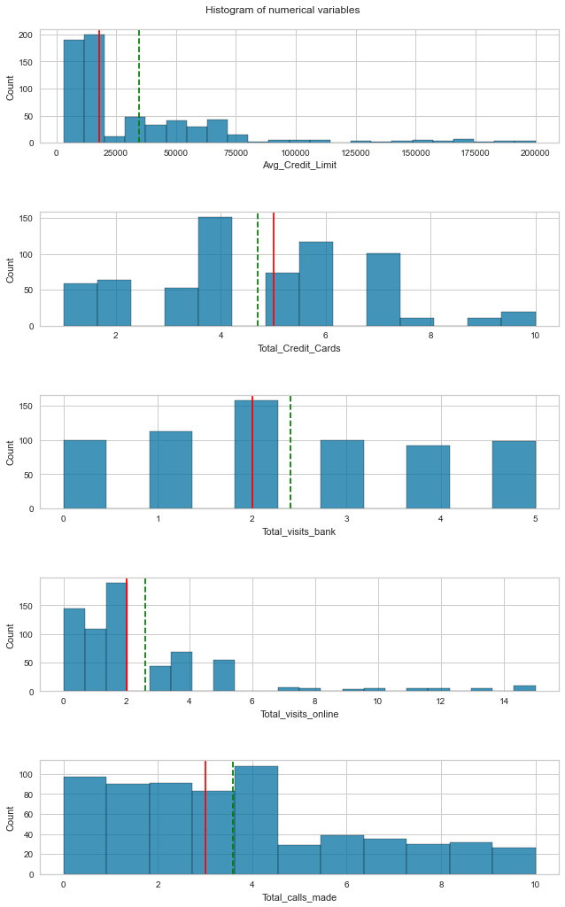

```python
#Histogram for all numerical columns (in this case all variables are numeric)
num_col = dataCC.select_dtypes(include=np.number).columns.tolist()

fig, axes = plt.subplots(5, 1,  figsize=(10, 15))
fig.suptitle('Histogram of numerical variables', fontsize=12)
counter = 0
for i in range(5):
    sns.histplot(x=dataCC[num_col[counter]],ax=axes[i])
    axes[i].axvline(np.mean(dataCC[num_col[counter]]), color='green', linestyle='--') # Add mean to the histogram
    axes[i].axvline(np.median(dataCC[num_col[counter]]), color='red', linestyle='-') # Add median to the histogram
    counter = counter+1

fig.tight_layout(pad=4.0)
```

#### Insights:

- Avg_Credit_Limit: Right skewed data with outliers at the right end, most of the data is concentrated towards the left end, two peak counts are below 25K
- Total_Credit_Cards:Not much skewed
- Total_visits_bank: Fairly normal distribution
- Total_visits_online: Right skewed data distribution
- Total_calls_made: Right skewed with most of the peak counts concentrated below 4

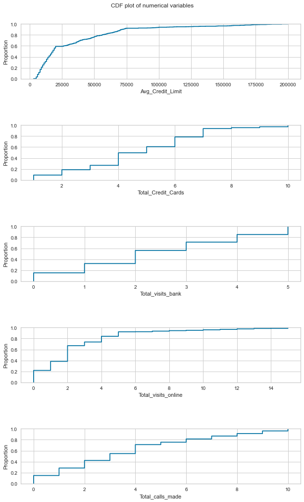

```python
#Cumulative Distribution (CDF) plot for all numerical columns (in this case all variables are numeric)
num_col = dataCC.select_dtypes(include=np.number).columns.tolist()

fig, axes = plt.subplots(5, 1,  figsize=(10, 15))
fig.suptitle('CDF plot of numerical variables', fontsize=12)
counter = 0
for i in range(5):
    sns.ecdfplot(x=dataCC[num_col[counter]],ax=axes[i])
    counter = counter+1

fig.tight_layout(pad=5.0)
```

#### Insights:

- 90 % of the customers have average credit limit less than 75000
- 90 % of the customers have less than 7 credit cards
- 80 % of the customers make less than 4 visits to bank
- 90 % of the customers access the bank website less than 5 times
- 80 % of the customers make less than 6 calls to bank

#### **Another good univariate analysis can be done using density plot of individual variables and that we can see in pairplot**

#### EDA - Bivariate analysis

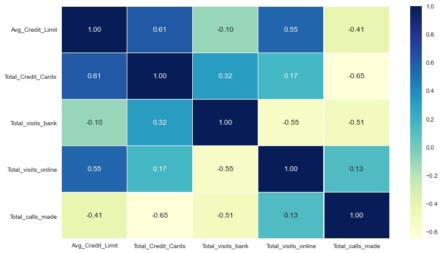

```python
#Heatmap to visualize the relationship between variables
#Here all 5 variables are numeric and is going to show in heatmap
fig, ax = plt.subplots(figsize=(12,7));
sns.heatmap(dataCC.corr(),annot=True,linewidths=0.1,cmap='YlGnBu',fmt='.2f');
```

#### Insights:

- Avg_Credit_Limit has +ve correlation with Total_Credit_Cards and Total_visits_online, it has -ve correlation with Total_calls_made
- Total_Credit_Cards has -ve correlation with Total_calls_made, it has some +ve correlation with Total_visits_bank
- Total_visits_bank has -ve correlation with Total_calls_made and Total_visits_online

#### Pairplot for pairwise analysis and density plot of individual features

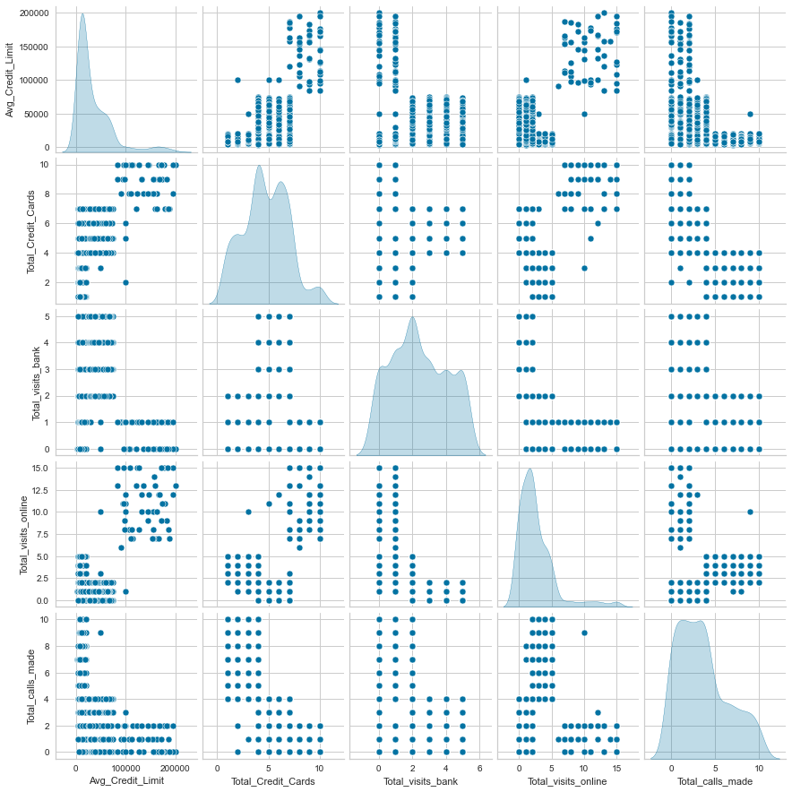

```python
#Pairplot for the dataset
sns.pairplot(data=dataCC,diag_kind='kde');
```

#### Insights:

- Pairplot confirms all +ve and -ve correlation that we saw in heatmap
- From the density plots of individual variables, we can see that some of these are multi-modal, indicating clusters of data
- Density plot of individual variables gives us an idea about minimum number of clusters, but when we combine features together it could be more
- Here it looks like we will have minimum 3 or 4 clusters, it could be more, we will explore further when we do clustering

#### Let us explore the correlation between variables that we saw in heatmap to see if there is strong linear relation

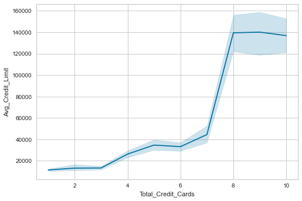

```python
#Avg_Credit_Limit Vs Total_Credit_Cards
sns.lineplot(y=dataCC.Avg_Credit_Limit, x=dataCC.Total_Credit_Cards);
```

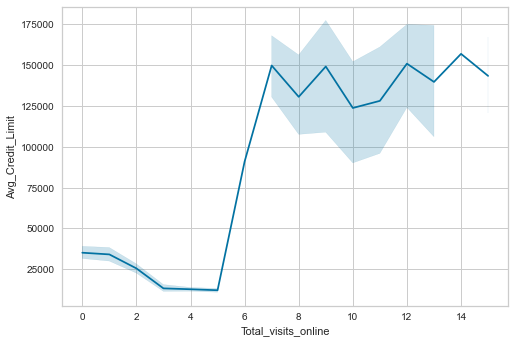

```python
#Avg_Credit_Limit Vs Total_visits_online
sns.lineplot(y=dataCC.Avg_Credit_Limit, x=dataCC.Total_visits_online);
```

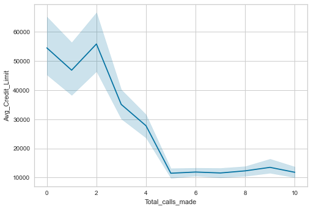

```python
#Avg_Credit_Limit Vs Total_calls_made
sns.lineplot(y=dataCC.Avg_Credit_Limit, x=dataCC.Total_calls_made);
```

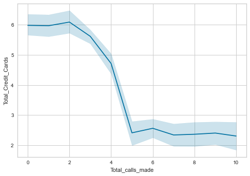

```python
#Total_Credit_Cards Vs Total_calls_made,
sns.lineplot(y=dataCC.Total_Credit_Cards, x=dataCC.Total_calls_made);
```

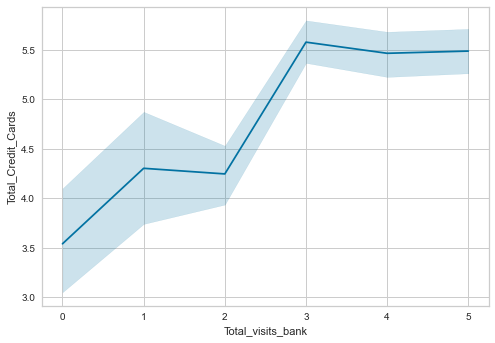

```python
#Total_Credit_Cards Vs Total_visits_bank,
sns.lineplot(y=dataCC.Total_Credit_Cards, x=dataCC.Total_visits_bank);
```

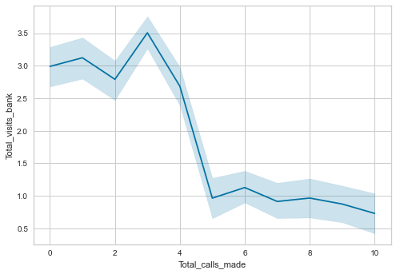

```python
#Total_visits_bank Vs Total_calls_made,
sns.lineplot(y=dataCC.Total_visits_bank, x=dataCC.Total_calls_made);
```

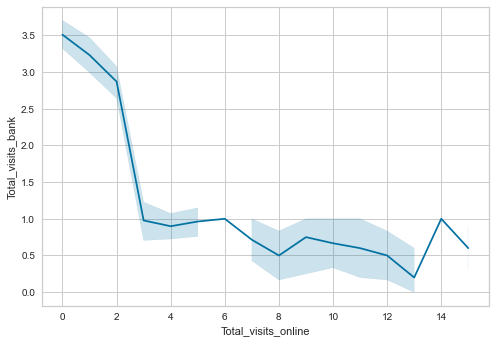

```python
#Total_visits_bank Vs Total_visits_online,
sns.lineplot(y=dataCC.Total_visits_bank, x=dataCC.Total_visits_online);
```

- The above plots show +ve and -ve correlation between variables that we already saw in heatmap, but these does not look like a very strong correlation

#### Key observations based on EDA

- % or number of customers with higher average credit limit is very less (around 10% only)
- % or number of customers visiting the bank often are very less (80% make less than 4 visits)
- % or number of customers visiting the bank website often are very less (90% make less than 5 visits)
- % or number of customers using calls to communicate with the bank are less (80% make less than 6 calls)
- From the above observations, it is clear that, customers are not using the bank support services much, bank can focus more on improvng the service delivery model, making sure that the customer requests or queries are resolved faster, that way more customers will make use of the support services
- Avg_Credit_Limit has +ve correlation with Total_Credit_Cards which makes sense. It has +ve correlation with Total_visits_online, this means that customers accessing online banking uses more credit cards.
- Total_Credit_Cards has some +ve correlation with Total_visits_bank, which means that customers visiting the bank often tend to use more credit card services
- Total_visits_bank has -ve correlation with Total_calls_made and Total_visits_online, which make sense, customers using phone calls to interact with the bank and online banking tend to make less visits to the bank directly

#### Treating outliers

```python
dataCC['Avg_Credit_Limit'] = dataCC['Avg_Credit_Limit'].apply(lambda x: x if x <= 105000 else 105000)
```

```python
dataCC['Total_visits_online'] = dataCC['Total_visits_online'].apply(lambda x: x if x <= 8 else 8)
```

#### Checking outliers % again to see if outliers are treated

```python
((dataCC < lower) | (dataCC > upper)).sum()/len(data)*100
```

```
Avg_Credit_Limit       0.0
Total_Credit_Cards     0.0
Total_visits_bank      0.0
Total_visits_online    0.0
Total_calls_made       0.0
dtype: float64
```

#### Scaling data before clustering

- It is important to scale the data and make different features on the same scale before doing unsupervised learning techniques, since unsupervised learning algorithms find similarity between data points and group them in clusters based on distance measures and the distance measures are scale dependent.

```python
# Scaling the dataset before clustering
#Here we are doing scaling using StandardScaler, it can also be done using z-score
scaler = StandardScaler()
dataCC_scaled = scaler.fit_transform(dataCC)
```

```python
#Creating a dataframe from the scaled data above
dataCC_scaled_df = pd.DataFrame(dataCC_scaled,columns=dataCC.columns)
```

```python
dataCC_scaled_df.head()
```

|  | Avg_Credit_Limit | Total_Credit_Cards | Total_visits_bank | Total_visits_online | Total_calls_made |
| --- | --- | --- | --- | --- | --- |
| 0 | 2.398942 | -1.249225 | -0.860451 | -0.627980 | -1.251537 |
| 1 | 0.643619 | -0.787585 | -1.473731 | 2.581387 | 1.891859 |
| 2 | 0.643619 | 1.058973 | -0.860451 | 0.288982 | 0.145528 |
| 3 | -0.058511 | 0.135694 | -0.860451 | -0.627980 | 0.145528 |
| 4 | 2.398942 | 0.597334 | -1.473731 | 2.581387 | -0.203739 |

```python
#Keeping a copy of the datasets to use for Hierarchical clustering, since the above ones are going to be used for Kmeans
dataCC_scaled_df_hc = dataCC_scaled_df.copy()
dataCC_hc = dataCC.copy()
```

```python
dataCC_scaled_df_hc.head()
```

|  | Avg_Credit_Limit | Total_Credit_Cards | Total_visits_bank | Total_visits_online | Total_calls_made |
| --- | --- | --- | --- | --- | --- |
| 0 | 2.398942 | -1.249225 | -0.860451 | -0.627980 | -1.251537 |
| 1 | 0.643619 | -0.787585 | -1.473731 | 2.581387 | 1.891859 |
| 2 | 0.643619 | 1.058973 | -0.860451 | 0.288982 | 0.145528 |
| 3 | -0.058511 | 0.135694 | -0.860451 | -0.627980 | 0.145528 |
| 4 | 2.398942 | 0.597334 | -1.473731 | 2.581387 | -0.203739 |

```python
dataCC.head()
```

|  | Avg_Credit_Limit | Total_Credit_Cards | Total_visits_bank | Total_visits_online | Total_calls_made |
| --- | --- | --- | --- | --- | --- |
| 0 | 100000 | 2 | 1 | 1 | 0 |
| 1 | 50000 | 3 | 0 | 8 | 9 |
| 2 | 50000 | 7 | 1 | 3 | 4 |
| 3 | 30000 | 5 | 1 | 1 | 4 |
| 4 | 100000 | 6 | 0 | 8 | 3 |

```python
dataCC_hc.head()
```

|  | Avg_Credit_Limit | Total_Credit_Cards | Total_visits_bank | Total_visits_online | Total_calls_made |
| --- | --- | --- | --- | --- | --- |
| 0 | 100000 | 2 | 1 | 1 | 0 |
| 1 | 50000 | 3 | 0 | 8 | 9 |
| 2 | 50000 | 7 | 1 | 3 | 4 |
| 3 | 30000 | 5 | 1 | 1 | 4 |
| 4 | 100000 | 6 | 0 | 8 | 3 |

#### Should we do PCA??

- PCA can be used to reduce dimensions, if the dataset has too many variables and there is a possibility of 'curse of dimensionality'
- PCA can also be used to remove multicollinearity to make the variables independent
- In the given dataset, from pairplot and heatmap, we have seen that, there are no strong correlation between variables
- And there are only 5 variables in this given dataset
- Considering these points, I believe, we do not need to do PCA for dimensionality reduction, will try using PCA transformed dataset on K-means and Hierarchical clustering to see if that gives a diff result
- We can apply PCA on the dataset to find patterns in data, which helps to identify clusters

#### PCA for preprocessing

```python
#apply PCA for all 5 variables
pca = PCA(n_components=5)
pca_data = pca.fit_transform(dataCC_scaled_df)
```

```python
#create a dataframe for pca results
pca_data_df = pd.DataFrame(data = pca_data, columns = ['component_1', 'component_2','component_3','component_4','component_5'])
```

```python
pca_data_df.head()
```

|  | component_1 | component_2 | component_3 | component_4 | component_5 |
| --- | --- | --- | --- | --- | --- |
| 0 | -0.726920 | 0.924770 | 2.682827 | 0.753045 | -0.931834 |
| 1 | 2.442035 | 2.537172 | -0.623864 | 0.700723 | -0.410012 |
| 2 | -0.307238 | 1.212364 | 0.055173 | -0.075930 | 0.898723 |
| 3 | 0.270407 | 0.000543 | 0.650165 | -0.216267 | 0.796959 |
| 4 | -0.192188 | 3.809281 | 0.185077 | 0.305259 | -0.560078 |

```python
print('Explained variance per principal component: {}'.format(pca.explained_variance_ratio_))
```

```
Explained variance per principal component: [0.47451323 0.34186059 0.06541837 0.06215495 0.05605285]
```

- The first principal component explains 47% of total variance in the data
- The second principal component explains 34% of total variance in the data
- The third principal component explains 7% of total variance in the data
- The fourth principal component explains 6% of total variance in the data
- The fifth principal component explains 6% of total variance in the data

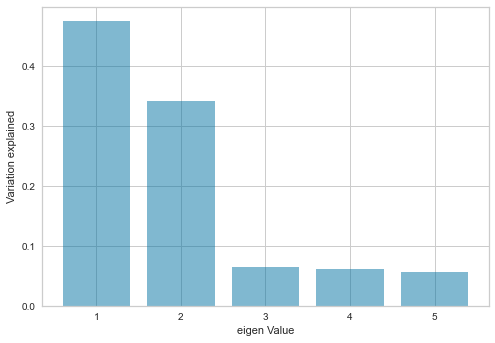

```python
#Visualize the variance explained
plt.bar(list(range(1,6)),pca.explained_variance_ratio_,alpha=0.5, align='center')
plt.ylabel('Variation explained')
plt.xlabel('eigen Value')
plt.show()
```

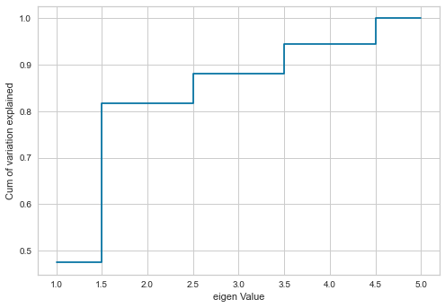

```python
#cumulative variance explained plot
plt.step(list(range(1,6)),np.cumsum(pca.explained_variance_ratio_), where='mid')
plt.ylabel('Cum of variation explained')
plt.xlabel('eigen Value')
plt.show()
```

- First two components alone can explain more than 80% of variance in the data
- With first 3 components, almost 90% of variance in data can be explained

#### Visualize the new components in pairplot to see patterns in data

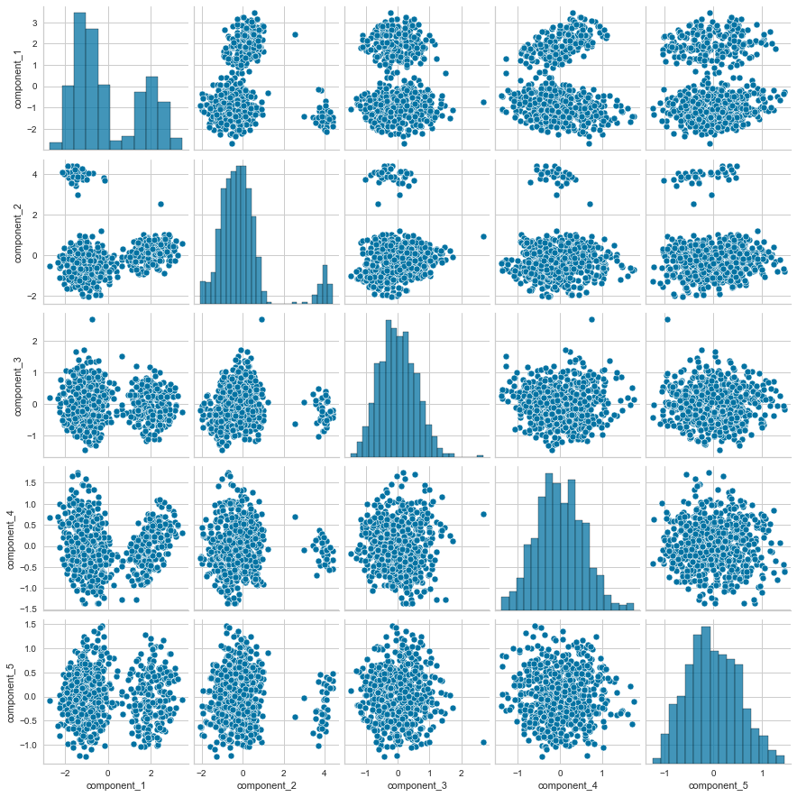

```python
#pairplot between pca component 1 and component 2
sns.pairplot(pca_data_df);
```

- The above plot kind of shows max 3 groups of data points, shows a possibility of 3 clusters
- We can further see grouping using clustering methods
- First K-means is going to be done using the scaled dataset before PCA and then will try with PCA transformed dataset too
- Same approach is going to be followed for Hierarchical clustering too

#### K-means clustering

- From density plot of individual variables (from pairplot) we saw that the minimum number of clusters could be 3 or 4
- So we can try different K values from 1 to 8 for K-means

```
Number of Clusters: 1 	Average Distortion: 2.0768825795967847
Number of Clusters: 2 	Average Distortion: 1.499388142948641
Number of Clusters: 3 	Average Distortion: 1.1854277062875789
Number of Clusters: 4 	Average Distortion: 1.0745748070766914
Number of Clusters: 5 	Average Distortion: 1.0085841692322477
Number of Clusters: 6 	Average Distortion: 0.9560513434333665
Number of Clusters: 7 	Average Distortion: 0.9190477648589387
Number of Clusters: 8 	Average Distortion: 0.8938781724511368
```

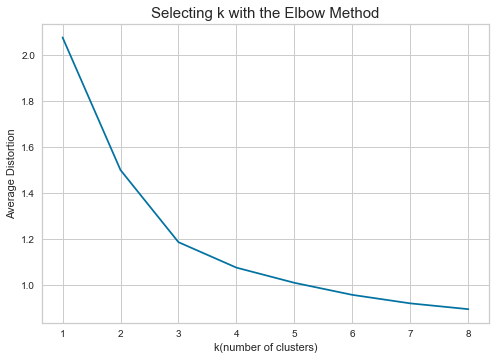

```python
#k values from 1 to 8
clusters = range(1,9)
meanDistortions = []

for k in clusters:
    model = KMeans(n_clusters=k)
    model.fit(dataCC_scaled_df)
    prediction = model.predict(dataCC_scaled_df)
    distortion = sum(np.min(cdist(dataCC_scaled_df, model.cluster_centers_, 'euclidean'), axis=1)) / dataCC_scaled_df.shape[0]

    meanDistortions.append(distortion)

    print('Number of Clusters:', k, '\tAverage Distortion:', distortion)

plt.plot(clusters, meanDistortions, 'bx-')
plt.xlabel('k(number of clusters)')
plt.ylabel('Average Distortion')
plt.title('Selecting k with the Elbow Method', fontsize=15)
```

- The appropriate value of k (number of clusters) from elbow curve seems to be 3

#### Checking Silhouette Score

- Silhouette score for a set of data points is used to measure how dense and well-separated the clusters are
- Silhouette score takes into consideration the intra-cluster distance between the sample and other data points within the same cluster and inter-cluster distance between the sample and the next nearest cluster
- The silhouette score falls within the range -1 to +1
- The silhouette score of 1 means that the clusters are very dense and nicely separated. The score of 0 means that clusters are overlapping. The score of less than 0 means that data belonging to clusters may be wrong/incorrect

```python
sil_score = []
cluster_list = list(range(2,10))
for n_cluster in cluster_list:
    m_cluster = KMeans(n_clusters=n_cluster)
    predict = m_cluster.fit_predict((dataCC_scaled_df))
    score = silhouette_score(dataCC_scaled_df, predict)
    sil_score.append(score)
    print("For n_clusters = {}, silhouette score is {})".format(n_cluster, score))
```

```
For n_clusters = 2, silhouette score is 0.4214157605438826)
For n_clusters = 3, silhouette score is 0.5174964658288138)
For n_clusters = 4, silhouette score is 0.3809234881879361)
For n_clusters = 5, silhouette score is 0.35283476687130977)
For n_clusters = 6, silhouette score is 0.2704453421260849)
For n_clusters = 7, silhouette score is 0.26642801386176457)
For n_clusters = 8, silhouette score is 0.2547500192771518)
For n_clusters = 9, silhouette score is 0.24679136108070254)
```

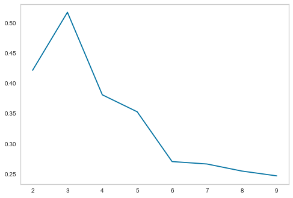

```python
#Plot Silhouette Score
plt.plot(cluster_list,sil_score)
plt.grid()
```

- From Silhouette Score, it looks like 3 is a good value of k (number of clusters)

#### Checking Silhouette plots for different values of k to find optimal number of clusters

- Trying values of k below and above the optimal value (3) found from Silhouette Score (2,3,4,5,6)
- Silhouette plots can be used to select the most optimal value of the K (number of cluster) in K-means clustering
- The aspects to look out for in Silhouette plots are
  - Cluster scores below the average silhouette score (good if all clusters are above average silhouette score)
  - Wide fluctuations in the size of the clusters (good if the size of clusters is more uniform)
  - The thickness of the silhouette plot (shows the number of data points in a cluster)

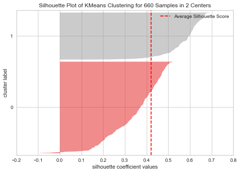

```python
#Finding optimal number of clusters with Silhouette coefficients, k=2
visualizer = SilhouetteVisualizer(KMeans(2, random_state = 1))
visualizer.fit(dataCC_scaled_df)
visualizer.show();
```

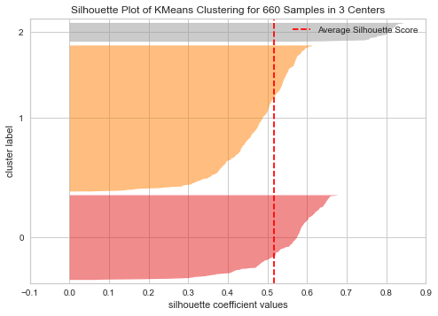

```python
#Finding optimal number of clusters with Silhouette coefficients, k=3
visualizer = SilhouetteVisualizer(KMeans(3, random_state = 1))
visualizer.fit(dataCC_scaled_df)
visualizer.show();
```

- For all 3 clusters, we don't see score -ve and most of the data points are above average score
- Cluster 2 shows less data points compared to cluster 0 and 1
- K=3 does look like a good value of K

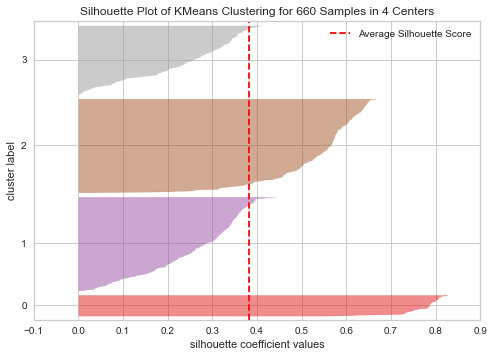

```python
#Finding optimal number of clusters with Silhouette coefficients, k=4
visualizer = SilhouetteVisualizer(KMeans(4, random_state = 1))
visualizer.fit(dataCC_scaled_df)
visualizer.show();
```

- For the clusters 3 and 1, most of the data points are below average score
- K=4 does not look like a good value of K

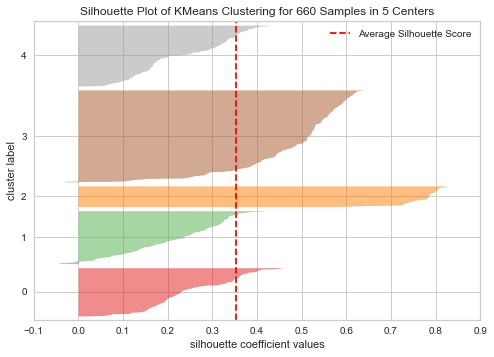

```python
#Finding optimal number of clusters with Silhouette coefficients, k=5
visualizer = SilhouetteVisualizer(KMeans(5, random_state = 1))
visualizer.fit(dataCC_scaled_df)
visualizer.show();
```

- For the cluster 3 and 1, some of the data points have -ve score
- For the clusters 4,1,0 more data points have below avg score
- K=5 does not look like a good value of K

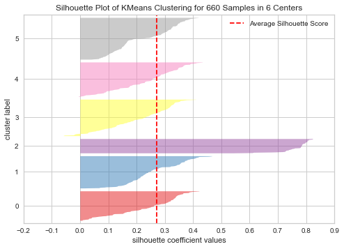

```python
#Finding optimal number of clusters with Silhouette coefficients, k=6
visualizer = SilhouetteVisualizer(KMeans(6, random_state = 1))
visualizer.fit(dataCC_scaled_df)
visualizer.show();
```

- For the cluster3, some of the data points have -ve score
- For the clusters 5,4,3,1,0 more data points have below avg score
- K=6 does not look like a good value of K

#### We can take 3 as appropriate number of clusters as Silhouette Score is high enough and there is knick at 3 in Elbow Curve

```python
#K-mean for k=3
kmeans = KMeans(n_clusters=3, random_state=1)
kmeans.fit(dataCC_scaled_df)
```

```
KMeans(n_clusters=3, random_state=1)
```

```python
#Adding cluster labels to the original dataset
dataCC['K_means_segments'] = kmeans.labels_
```

```python
#Adding cluster labels to the scaled dataset
dataCC_scaled_df['K_means_segments'] = kmeans.labels_
```

```python
#Cluster profile based on scaled dataset
cluster_profile = dataCC.groupby('K_means_segments').mean()
```

```python
cluster_profile['count_in_each_segment_kmeans'] = dataCC.groupby('K_means_segments')['Total_Credit_Cards'].count().values
```

#### Cluster profile

```python
# To display cluster profile
cluster_profile.style.highlight_max(color = 'lightgreen', axis = 0)
```

| K_means_segments | Avg_Credit_Limit | Total_Credit_Cards | Total_visits_bank | Total_visits_online | Total_calls_made | count_in_each_segment_kmeans |
| --- | --- | --- | --- | --- | --- | --- |
| 0 | 12174.107143 | 2.410714 | 0.933036 | 3.544643 | 6.870536 | 224 |
| 1 | 33782.383420 | 5.515544 | 3.489637 | 0.981865 | 2.000000 | 386 |
| 2 | 102660.000000 | 8.740000 | 0.600000 | 7.820000 | 1.080000 | 50 |

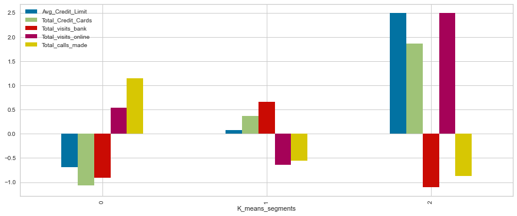

```python
dataCC_scaled_df.groupby('K_means_segments').mean().plot.bar(figsize=(15,6));
```

- Eventhough the above plot is showing +ve and -ve values together based on 0, it still shows low,medium,high values across 3 clusters

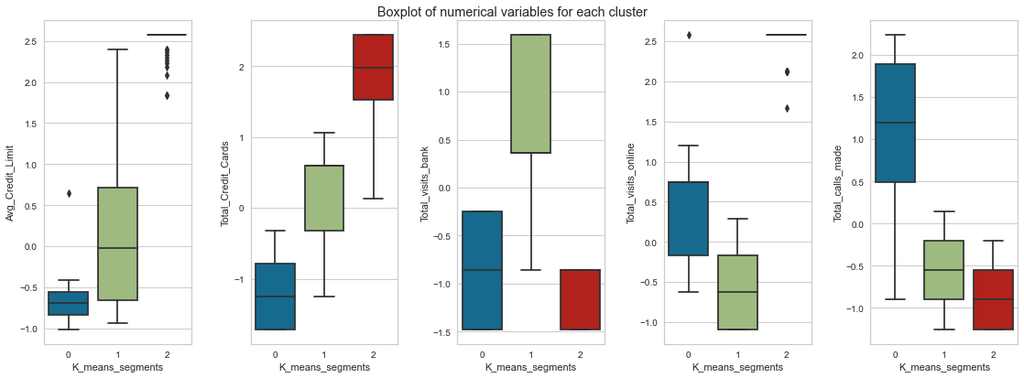

```python
#Boxplot of numerical variables for each cluster, in this dataset all are numerical variables
#For boxplot scaled dataset is used to see the distribution of variables on the same scale
all_col = dataCC_scaled_df.iloc[:,0:].columns.tolist()
fig, axes = plt.subplots(1, 5,  figsize=(16, 6))
fig.suptitle('Boxplot of numerical variables for each cluster')
counter = 0
for i in range(5):
    sns.boxplot(ax=axes[i],y=dataCC_scaled_df[all_col[counter]],x=dataCC_scaled_df['K_means_segments'])
    counter = counter+1

fig.tight_layout(pad=2.0)
```

#### Insights from K-means

- Cluster 0:
  - Avg_Credit_Limit is lowest for this cluster
  - Number of credit cards is also lowest for this cluster
  - Number of visits to bank is medium, when compared to other 2 clusters
  - Number of online website visits is also medium, when compared to other 2 clusters
  - Number of calls made to bank is highest, when compared to other 2 clusters
  - Number of data points in this cluster is in between when comparing all 3 clusters
  - This cluster can be thought of as a group of customers who prefer to call the bank, have less number of credit cards, have less interaction with bank online and through direct visits
- Cluster 1:
  - Avg_Credit_Limit is medium, when compared to other 2 clusters
  - Number of credit cards is also medium, when compared to other 2 clusters
  - Number of visits to bank is highest, when compared to other 2 clusters
  - Number of online website visits is lowest for this cluster
  - Number of calls made to bank is medium, when compared to other 2 clusters
  - Number of data points in this cluster is more than other 2 clusters
  - This cluster can be thought of as a group of customers who prefer direct bank visits, have more number of credit cards than cluster 0 customers, have less interaction with bank online and through calls
- Cluster 2:
  - Avg_Credit_Limit is highest, when compared to other 2 clusters
  - Number of credit cards is also highest, when compared to other 2 clusters
  - Number of visits to bank is lowest for this cluster
  - Number of online website visits is highest for this cluster
  - Number of calls made to bank is lowest, when compared to other 2 clusters
  - Number of data points in this cluster is less than other 2 clusters
  - This cluster can be thought of as a group of customers who prefer online interactions with bank, have more number of credit cards than cluster 0 and 1 customers, have less interaction with bank through calls and direct visits

#### Business Recommendations based on K-means

- **Cluster 0**: This cluster can be thought of as a group of customers who prefer to call bank for diff services, have less number of credit cards, have less interaction with bank online and through direct visits
  - **Recommendation**:
    - Based on the given dataset,this group is almost 34% of customers.Since these customers prefer to call the bank and have less number of credit cards, bank marketing team can call these customers as part of personalised campaign and talk to them more about credit cards offered by bank, their benefits and even give them some offers to make them use more credit card related products.
    - In another way, we can think that these customers prefer interactions through calls, may be because they are not happy with the online services provided, which bank can consider as an improvement area. This group has less credit card usage, by improving services through call and focusing on enabling better online interactions for this group, bank can improve customer satisfaction, which in turn makes the customers use more produtcs like credit cards.
    - Less credit card usage for this group indicates gap in credit card services provided through calls
- **Cluster 1**: This cluster can be thought of as a group of customers who prefer direct bank visits, have more number of credit cards than cluster 0 customers, have less interaction with bank online and through calls
  - **Recommendation**:
    - Based on the given dataset,this group is almost 58%(more than half) of customers.Since these customers prefer to visit the bank in person and use less online banking, bank marketing team can talk to them when they visit the bank about products (credit cards etc), about benefits of using bank website for their interactions with the bank. Also have a dedicated personalised campaign desk at the bank to focus these customers and know more about their interests on various products including credit cards and find how to make them use more of these bank products.
    - In another way, we can think that these customers prefer interactions through direct visits, may be because they are not happy with the online services provided and not happy with services provided through calls, which bank can consider as an improvement area.By improving services through calls and services provided online, bank can improve customer satisfaction, which in turn makes the customers use more produtcs like credit cards.
- **Cluster 2**: This cluster can be thought of as a group of customers who prefer online interactions with bank, have more number of credit cards than cluster 0 and 1 customers, have less interaction with bank through calls and direct visits
  - **Recommendation**:
    - Based on the given dataset,this group is only 8% of customers, but contribute most towards credit card usage. Since these customers prefer to access bank website for their interactions with the bank, bank marketing team can launch personalised campaign and other services online for these customers, give them option to use chat bots etc to know more about their interests on various products including credit cards, and find out how to retain these customers in terms of credit card usage and improve further more
    - Bank might prefer more customers to start using online services. By improving services provided online, resolving queries faster and better addressing gaps in services, adding more and more services to online website, bank can make more customers move to this cluster, which in turn helps bank reduce manual work load and staff can better focus on other areas
    - Highest credit card usage for this group indicates credit card services provided online are good and can be thought of using for other 2 categories

#### K-means using PCA transformed dataset (only first 2 components)

```python
pca_subset = pca_data_df[['component_1','component_2']]

#Silhouette score using PCA dataset
sil_score = []
cluster_list = list(range(2,10))
for n_cluster in cluster_list:
    m_cluster = KMeans(n_clusters=n_cluster)
    predict = m_cluster.fit_predict((pca_subset))
    score = silhouette_score(pca_subset, predict)
    sil_score.append(score)
    print("For n_clusters = {}, silhouette score is {})".format(n_cluster, score))
```

```
For n_clusters = 2, silhouette score is 0.5632301437952184)
For n_clusters = 3, silhouette score is 0.6840343495186236)
For n_clusters = 4, silhouette score is 0.4968660933555495)
For n_clusters = 5, silhouette score is 0.48510458876266044)
For n_clusters = 6, silhouette score is 0.39044873709586797)
For n_clusters = 7, silhouette score is 0.38539738377711874)
For n_clusters = 8, silhouette score is 0.3943131902779746)
For n_clusters = 9, silhouette score is 0.38848729522850955)
```

- Silhouette score is the highest for number of clusters = 3 (same as that of using original dataset)

```python
#K-means with number of clusters = 3, using PCA dataset
kmeans = KMeans(n_clusters=3, random_state=1)
kmeans.fit(pca_subset)
```

```
KMeans(n_clusters=3, random_state=1)
```

```python
#Adding cluster labels to the PCA dataset
pca_subset['K_means_segments'] = kmeans.labels_
```

```python
pca_subset.head()
```

|  | component_1 | component_2 | K_means_segments |
| --- | --- | --- | --- |
| 0 | -0.726920 | 0.924770 | 0 |
| 1 | 2.442035 | 2.537172 | 1 |
| 2 | -0.307238 | 1.212364 | 0 |
| 3 | 0.270407 | 0.000543 | 0 |
| 4 | -0.192188 | 3.809281 | 2 |

```python
#dataCC.drop('K_means_segments',axis=1)
```

```python
#merging all columns from original dataset except K-means labels, with results from K-means using pca dataset
pca_result_kmeans = pd.concat([dataCC.drop('K_means_segments',axis=1), pca_subset], axis=1, join="inner")
```

```python
pca_result_kmeans.head()
```

|  | Avg_Credit_Limit | Total_Credit_Cards | Total_visits_bank | Total_visits_online | Total_calls_made | component_1 | component_2 | K_means_segments |
| --- | --- | --- | --- | --- | --- | --- | --- | --- |
| 0 | 100000 | 2 | 1 | 1 | 0 | -0.726920 | 0.924770 | 0 |
| 1 | 50000 | 3 | 0 | 8 | 9 | 2.442035 | 2.537172 | 1 |
| 2 | 50000 | 7 | 1 | 3 | 4 | -0.307238 | 1.212364 | 0 |
| 3 | 30000 | 5 | 1 | 1 | 4 | 0.270407 | 0.000543 | 0 |
| 4 | 100000 | 6 | 0 | 8 | 3 | -0.192188 | 3.809281 | 2 |

```python
#cluster profile using pca results
cluster_profile_pca_kmeans = pca_result_kmeans.groupby(['K_means_segments']).mean()
cluster_profile_pca_kmeans['count_in_each_segment_kmeans'] = pca_result_kmeans.groupby('K_means_segments')['Total_Credit_Cards'].count().values
cluster_profile_pca_kmeans
```

| K_means_segments | Avg_Credit_Limit | Total_Credit_Cards | Total_visits_bank | Total_visits_online | Total_calls_made | component_1 | component_2 | count_in_each_segment_kmeans |
| --- | --- | --- | --- | --- | --- | --- | --- | --- |
| 0 | 33782.383420 | 5.515544 | 3.489637 | 0.981865 | 2.000000 | -0.967685 | -0.600185 | 386 |
| 1 | 12174.107143 | 2.410714 | 0.933036 | 3.544643 | 6.870536 | 1.996917 | 0.151327 | 224 |
| 2 | 102660.000000 | 8.740000 | 0.600000 | 7.820000 | 1.080000 | -1.475661 | 3.955482 | 50 |

#### Cluster Profile K-means using PCA

```python
# To display cluster profile
cluster_profile_pca_kmeans.style.highlight_max(color = 'yellow', axis = 0)
```

| K_means_segments | Avg_Credit_Limit | Total_Credit_Cards | Total_visits_bank | Total_visits_online | Total_calls_made | component_1 | component_2 | count_in_each_segment_kmeans |
| --- | --- | --- | --- | --- | --- | --- | --- | --- |
| 0 | 33782.383420 | 5.515544 | 3.489637 | 0.981865 | 2.000000 | -0.967685 | -0.600185 | 386 |
| 1 | 12174.107143 | 2.410714 | 0.933036 | 3.544643 | 6.870536 | 1.996917 | 0.151327 | 224 |
| 2 | 102660.000000 | 8.740000 | 0.600000 | 7.820000 | 1.080000 | -1.475661 | 3.955482 | 50 |

#### Insight:

- K-means using PCA transformed dataset gives similar results compared to using original dataset without PCA
- Silhouette score improved with PCA
- Since cluster profile is not changed, insights and business recommendations made using original dataset still holds true

#### Hierarchical Clustering

- Going to use cophenetic correlation and dendrograms to find the optimal value of clusters
- cophenetic correlation is a measure of the correlation between the distance of points in feature space and distance on dendrogram
- closer it is to 1, the better is the clustering

#### Linkage methods and distance metrics

- We will work with distance metrics - euclidean,chebyshev,mahalanobis,cityblock and linkage methods - single,complete,average,weighted,centroid,median,ward
- 'centroid', 'median','ward' linkage methods requires Euclidean distance metric
- So we will first calculate 'cophenetic correlation' with other distance metrics and different linkage methods
- Then we will calculate 'cophenetic correlation' with euclidean distance and different linkage methods

```python
#checking the datasets to see if the new columns added for kmeans are not in these
dataCC_scaled_df_hc.head()
```

|  | Avg_Credit_Limit | Total_Credit_Cards | Total_visits_bank | Total_visits_online | Total_calls_made |
| --- | --- | --- | --- | --- | --- |
| 0 | 2.398942 | -1.249225 | -0.860451 | -0.627980 | -1.251537 |
| 1 | 0.643619 | -0.787585 | -1.473731 | 2.581387 | 1.891859 |
| 2 | 0.643619 | 1.058973 | -0.860451 | 0.288982 | 0.145528 |
| 3 | -0.058511 | 0.135694 | -0.860451 | -0.627980 | 0.145528 |
| 4 | 2.398942 | 0.597334 | -1.473731 | 2.581387 | -0.203739 |

```python
dataCC_hc.head()
```

|  | Avg_Credit_Limit | Total_Credit_Cards | Total_visits_bank | Total_visits_online | Total_calls_made |
| --- | --- | --- | --- | --- | --- |
| 0 | 100000 | 2 | 1 | 1 | 0 |
| 1 | 50000 | 3 | 0 | 8 | 9 |
| 2 | 50000 | 7 | 1 | 3 | 4 |
| 3 | 30000 | 5 | 1 | 1 | 4 |
| 4 | 100000 | 6 | 0 | 8 | 3 |

```python
#finds out the cophenetic correlation for different distance measures and linkage methods
distance_metrics = [ 'chebyshev','mahalanobis','cityblock']
linkage_methods = ['single', 'complete', 'average','weighted']
high_cophenet_corr = 0
high_dm_lm = [0,0]
cophenet_corr_dm_lm = []
for dm in distance_metrics:
    for lm in linkage_methods:
        Z = linkage(dataCC_scaled_df_hc, metric=dm, method=lm)
        c, coph_dists = cophenet(Z , pdist(dataCC_scaled_df_hc))
        #print('Cophenetic correlation for distance metrics {} and linkage method {} is {}'.format(dm,lm,c))
        cophenet_corr_dm_lm.append([lm,dm,c])
        if high_cophenet_corr < c:
            high_cophenet_corr = c
            high_dm_lm[0] = dm
            high_dm_lm[1] = lm
```

```python
print('Highest Cophenetic Correlation is {}, which is obtained with {} distance metric and {} linkage method'.format(high_cophenet_corr ,high_dm_lm[0],high_dm_lm[1]))
```

```
Highest Cophenetic Correlation is 0.8900302370667433, which is obtained with cityblock distance metric and average linkage method
```

```python
pd.DataFrame(cophenet_corr_dm_lm, columns=['linkage','distance','Cophenetic Correlation']).sort_values(by='Cophenetic Correlation',ascending=False)
```

|  | linkage | distance | Cophenetic Correlation |
| --- | --- | --- | --- |
| 10 | average | cityblock | 0.890030 |
| 2 | average | chebyshev | 0.887877 |
| 3 | weighted | chebyshev | 0.885221 |
| 11 | weighted | cityblock | 0.864881 |
| 9 | complete | cityblock | 0.834767 |
| 6 | average | mahalanobis | 0.793875 |
| 1 | complete | chebyshev | 0.749559 |
| 0 | single | chebyshev | 0.680696 |
| 8 | single | cityblock | 0.663769 |
| 4 | single | mahalanobis | 0.650152 |
| 7 | weighted | mahalanobis | 0.612940 |
| 5 | complete | mahalanobis | 0.401130 |

#### Euclidean distance metric for 'centroid', 'median','ward' linkage methods

- 'centroid', 'median','ward' linkage methods requires Euclidean distance metric

```python
#finds out the cophenetic correlation for different linkage methods (centroid,median,ward) and Euclidean distance metric
linkage_methods = ['centroid','median','ward','single','complete','average','weighted']
high_cophenet_corr = 0
high_dm_lm = [0,0]
cophenet_corr_dm_lm = []
for lm in linkage_methods:
    Z = linkage(dataCC_scaled_df_hc, metric='euclidean', method=lm)
    c, coph_dists = cophenet(Z , pdist(dataCC_scaled_df_hc))
    #print('Cophenetic Correlation for distance metrics {} and linkage method {} is {}'.format('euclidean',lm,c))
    cophenet_corr_dm_lm.append([lm,'euclidean',c])
    if high_cophenet_corr < c:
        high_cophenet_corr = c
        high_dm_lm[0] = 'euclidean'
        high_dm_lm[1] = lm
#print('*'*110)
```

```python
print('Highest Cophenetic Correlation is {}, which is obtained with {} distance metric and {} linkage method'.format(high_cophenet_corr ,high_dm_lm[0],high_dm_lm[1]))
```

```
Highest Cophenetic Correlation is 0.8914250894994677, which is obtained with euclidean distance metric and average linkage method
```

```python
pd.DataFrame(cophenet_corr_dm_lm, columns=['linkage','distance','Cophenetic Correlation']).sort_values(by='Cophenetic Correlation',ascending=False)
```

|  | linkage | distance | Cophenetic Correlation |
| --- | --- | --- | --- |
| 5 | average | euclidean | 0.891425 |
| 0 | centroid | euclidean | 0.886704 |
| 6 | weighted | euclidean | 0.886530 |
| 1 | median | euclidean | 0.862956 |
| 4 | complete | euclidean | 0.831217 |
| 2 | ward | euclidean | 0.770322 |
| 3 | single | euclidean | 0.657448 |

- We can see from the above 2 analysis with different distance metrics and linkage methods that, euclidean distance metric and average linkage method give the best Cophenetic Correlation

#### Dendrogram for different linkage methods with euclidean distance metric

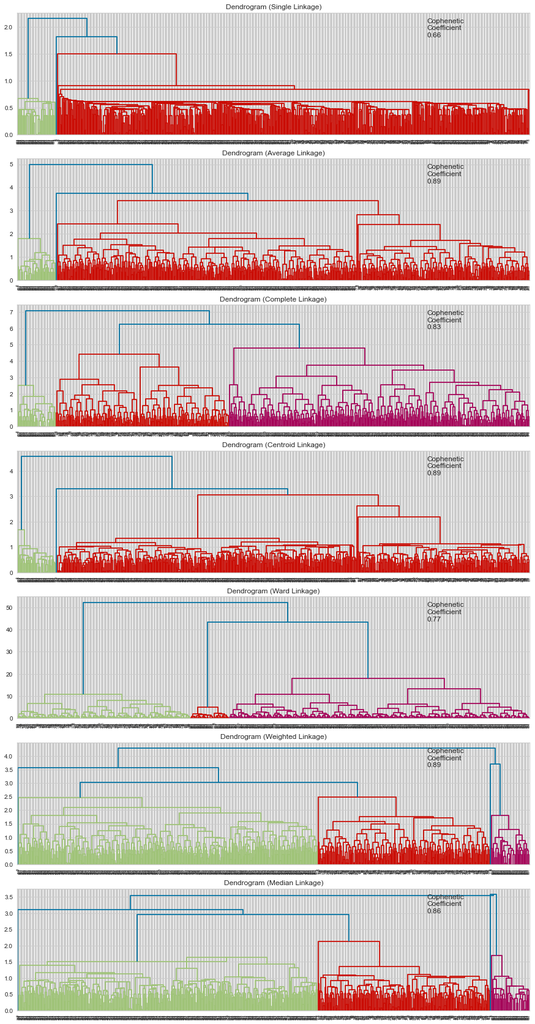

```python
# List of all linkage methods to check
methods = ['single',
           'average',
           'complete',
           'centroid',
           'ward',
          'weighted',
          'median']

# Create lists to save results of cophenetic correlation
compare_cols = ['Linkage Method', 'Cophenetic Coefficient']
compare = []

# Create a subplot image
fig, axs = plt.subplots(len(methods), 1, figsize=(15, 30))

# Loop through the list of all linkage methods defined in the list 'methods'

# Get linkage, plot dendrogram, calculate cophenetic coefficient

for i, method in enumerate(methods):

    Z = linkage(dataCC_scaled_df_hc, metric='euclidean', method=method)

    dendrogram(Z, ax=axs[i]);

    axs[i].set_title(f'Dendrogram ({method.capitalize()} Linkage)')

    coph_corr, coph_dist = cophenet(Z, pdist(dataCC_scaled_df_hc))

    axs[i].annotate(f'Cophenetic\nCoefficient\n{coph_corr:0.2f}',
                    (0.80, 0.80),
                    xycoords='axes fraction')

    compare.append([method, coph_corr])
```

- Dendrogram with ward linkage method shows distinct and separate clusters

```python
# Creating a dataframe to compare Cophenetic Coefficient for each linkage method
df_cophenetic_corr = pd.DataFrame(compare, columns=compare_cols)
df_cophenetic_corr.sort_values(by='Cophenetic Coefficient',ascending=False)
```

|  | Linkage Method | Cophenetic Coefficient |
| --- | --- | --- |
| 1 | average | 0.891425 |
| 3 | centroid | 0.886704 |
| 5 | weighted | 0.886530 |
| 6 | median | 0.862956 |
| 2 | complete | 0.831217 |
| 4 | ward | 0.770322 |
| 0 | single | 0.657448 |

- We can also see the dendrogram of 'chebyshev','cityblock','mahalanobis' with 'average', 'weighted','complete' linkage methods as they gave high cophenetic correlation values

```python
distance_metrics = [ 'chebyshev','cityblock','mahalanobis']
linkage_methods = ['average', 'weighted','complete']
```

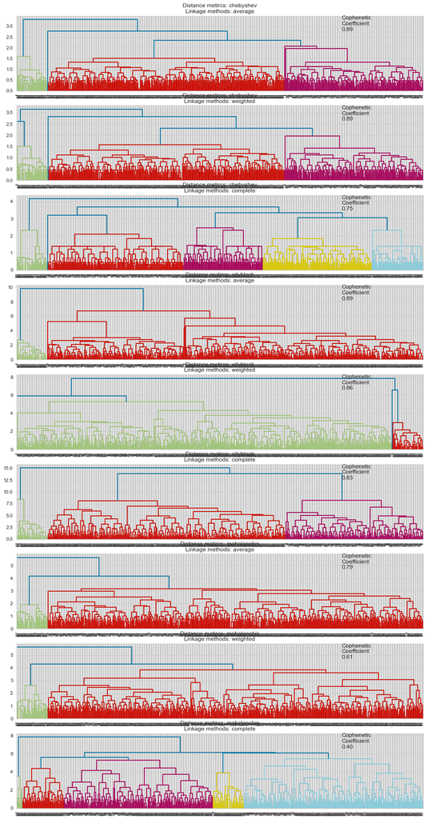

```python
# Create a subplot image
fig, axs = plt.subplots((len(distance_metrics)*len(linkage_methods)), 1, figsize=(15, 30))
i=0
for dm in distance_metrics:
    for lm in linkage_methods:
        Z = linkage(dataCC_scaled_df_hc, metric=dm, method=lm)
        dendrogram(Z,  ax=axs[i]);
        axs[i].set_title('Distance metircs: {}\nLinkage methods: {}'.format(dm,lm))
        coph_corr, coph_dist = cophenet(Z, pdist(dataCC_scaled_df_hc))
        axs[i].annotate(f'Cophenetic\nCoefficient\n{coph_corr:0.2f}',
                        (0.80, 0.80),
                        xycoords='axes fraction')
        axs[i].set_title('Distance metircs: {}\nLinkage methods: {}'.format(dm,lm))
        i +=1
```

- Out of all the dendrograms we saw above, it is clear that dendrogram with ward linkage method gave us separate and distinct clusters
- With 'ward' linkage method and 'euclidean' distance metric, it looks like 3 or 4 is an appropriate number of clusters

```python
#making sure the scaled dataset columns before calculating silhouette score
dataCC_scaled_df_hc.head()
```

|  | Avg_Credit_Limit | Total_Credit_Cards | Total_visits_bank | Total_visits_online | Total_calls_made |
| --- | --- | --- | --- | --- | --- |
| 0 | 2.398942 | -1.249225 | -0.860451 | -0.627980 | -1.251537 |
| 1 | 0.643619 | -0.787585 | -1.473731 | 2.581387 | 1.891859 |
| 2 | 0.643619 | 1.058973 | -0.860451 | 0.288982 | 0.145528 |
| 3 | -0.058511 | 0.135694 | -0.860451 | -0.627980 | 0.145528 |
| 4 | 2.398942 | 0.597334 | -1.473731 | 2.581387 | -0.203739 |

```python
#Silhouette Score using fcluster ward
Z = linkage(dataCC_scaled_df, method='ward',metric='euclidean')
clusters = fcluster(Z, 3, criterion='maxclust')
#clusters
silhouette_score(dataCC_scaled_df_hc,clusters)
```

```
0.5174964658288138
```

```python
#Silhouette Score using fcluster ward
Z = linkage(dataCC_scaled_df, method='ward',metric='euclidean')
clusters = fcluster(Z, 4, criterion='maxclust')
#clusters
silhouette_score(dataCC_scaled_df_hc,clusters)
```

```
0.3596306741085245
```

- Based on Silhouette Score, 3 is optimal number of clusters

#### Agglomerative Clustering with number of clusters = 3

```python
#Agglomerative Clustering with 3 clusters and ward linkage
HCmodel = AgglomerativeClustering(n_clusters=3,affinity='euclidean', linkage='ward')
HCmodel.fit(dataCC_scaled_df_hc)
```

```
AgglomerativeClustering(n_clusters=3)
```

#### Silhouette Score for Hierarchical Clustering with ward linkage

```python
silhouette_score(dataCC_scaled_df_hc,HCmodel.labels_)
```

```
0.5175822701797901
```

```python
#adding cluster labels to scaled dataset
dataCC_scaled_df_hc['HC_Clusters'] = HCmodel.labels_
```

```python
#adding cluster labels to original dataset too
dataCC_hc['HC_Clusters'] = HCmodel.labels_
```

```python
#dataCC_hc.head()
```

#### Cluster profile

```python
#mean
cluster_profile_1 = dataCC_hc.groupby('HC_Clusters').mean()
```

```python
#count of data points in each cluster
cluster_profile_1['count_in_each_segments_hccluster'] = dataCC_hc.groupby('HC_Clusters')['Total_Credit_Cards'].count().values
```

```python
#displaying cluster profile
cluster_profile_1.style.highlight_max(color = 'lightgreen', axis = 0)
```

| HC_Clusters | Avg_Credit_Limit | Total_Credit_Cards | Total_visits_bank | Total_visits_online | Total_calls_made | count_in_each_segments_hccluster |
| --- | --- | --- | --- | --- | --- | --- |
| 0 | 33713.178295 | 5.511628 | 3.485788 | 0.984496 | 2.005168 | 387 |
| 1 | 12197.309417 | 2.403587 | 0.928251 | 3.551570 | 6.883408 | 223 |
| 2 | 102660.000000 | 8.740000 | 0.600000 | 7.820000 | 1.080000 | 50 |

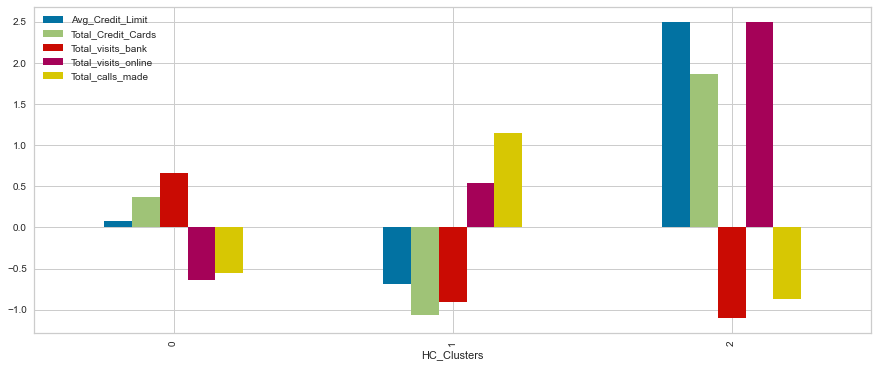

```python
dataCC_scaled_df_hc.groupby('HC_Clusters').mean().plot.bar(figsize=(15,6));
```

- Eventhough the above plot is showing +ve and -ve values together based on 0, it still shows low,medium,high values across 3 clusters

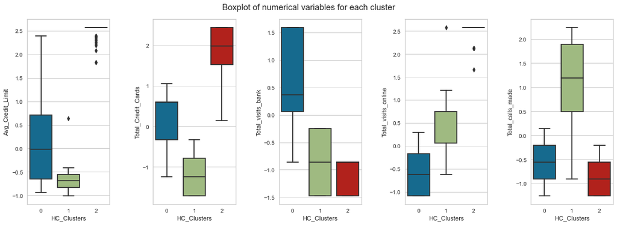

```python
fig, axes = plt.subplots(1, 5,  figsize=(16, 6))
fig.suptitle('Boxplot of numerical variables for each cluster', fontsize=15)
counter = 0
for ii in range(5):
    sns.boxplot(ax=axes[ii],y=dataCC_scaled_df_hc[all_col[counter]],x=dataCC_scaled_df_hc['HC_Clusters'])
    counter = counter+1

fig.tight_layout(pad=3.0)
```

```python
#Agglomerative Clustering with 3 clusters and average linkage
HCmodel = AgglomerativeClustering(n_clusters=3,affinity='euclidean', linkage='average')
HCmodel.fit(dataCC_scaled_df_hc)
```

```
AgglomerativeClustering(linkage='average', n_clusters=3)
```

#### Silhouette Score for Hierarchical Clustering with average linkage

```python
silhouette_score(dataCC_scaled_df_hc.drop('HC_Clusters',axis=1),HCmodel.labels_)
```

```
0.5175822701797901
```

```python
#adding cluster labels to scaled dataset
dataCC_scaled_df_hc['HC_Clusters'] = HCmodel.labels_
```

```python
#adding cluster labels to original dataset too
dataCC_hc['HC_Clusters'] = HCmodel.labels_
```

```python
#dataCC_hc.head()
```

#### Cluster profile

```python
#mean
cluster_profile_1 = dataCC_hc.groupby('HC_Clusters').mean()
```

```python
#count of data points in each cluster
cluster_profile_1['count_in_each_segments_hccluster'] = dataCC_hc.groupby('HC_Clusters')['Total_Credit_Cards'].count().values
```

```python
#displaying cluster profile
cluster_profile_1.style.highlight_max(color = 'lightgreen', axis = 0)
```

| HC_Clusters | Avg_Credit_Limit | Total_Credit_Cards | Total_visits_bank | Total_visits_online | Total_calls_made | count_in_each_segments_hccluster |
| --- | --- | --- | --- | --- | --- | --- |
| 0 | 33713.178295 | 5.511628 | 3.485788 | 0.984496 | 2.005168 | 387 |
| 1 | 102660.000000 | 8.740000 | 0.600000 | 7.820000 | 1.080000 | 50 |
| 2 | 12197.309417 | 2.403587 | 0.928251 | 3.551570 | 6.883408 | 223 |

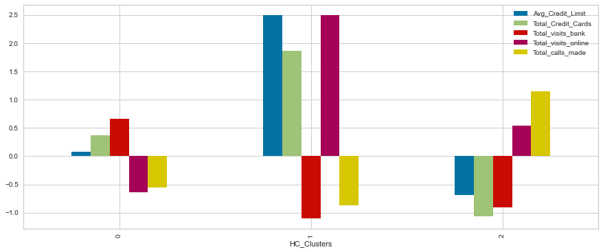

```python
dataCC_scaled_df_hc.groupby('HC_Clusters').mean().plot.bar(figsize=(15,6));
```

- Eventhough the above plot is showing +ve and -ve values together based on 0, it still shows low,medium,high values across 3 clusters
- With different linkage methods, only the cluster labels change

#### Final dendrogram with 3 clusters and truncate_mode upto 3 levels

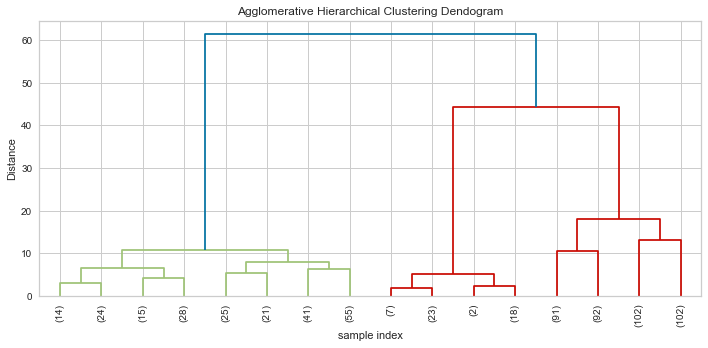

```python
#Dendrogram with 3 clusters and ward linkage
plt.figure(figsize=(10, 5))
plt.title('Agglomerative Hierarchical Clustering Dendogram')
plt.xlabel('sample index')
plt.ylabel('Distance')
Z = linkage(dataCC_scaled_df_hc, method='ward')
dendrogram(Z,leaf_rotation=90.0,p=3,color_threshold=52,leaf_font_size=10,truncate_mode='level')
plt.tight_layout()
```

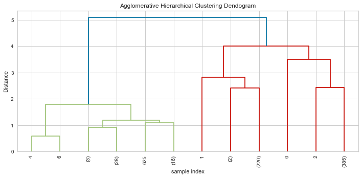

```python
#Dendrogram with 3 clusters and average linkage
plt.figure(figsize=(10, 5))
plt.title('Agglomerative Hierarchical Clustering Dendogram')
plt.xlabel('sample index')
plt.ylabel('Distance')
Z = linkage(dataCC_scaled_df_hc, method='average')
dendrogram(Z,leaf_rotation=90.0,p=3,color_threshold=5,leaf_font_size=10,truncate_mode='level')
plt.tight_layout()
```

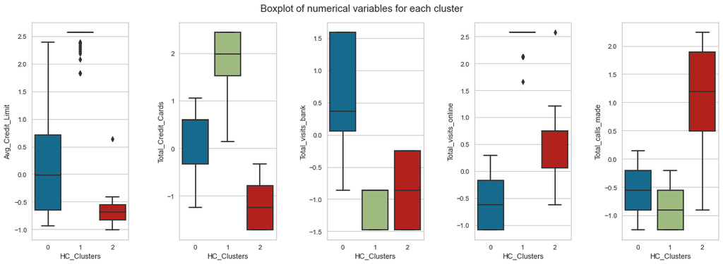

```python
fig, axes = plt.subplots(1, 5,  figsize=(16, 6))
fig.suptitle('Boxplot of numerical variables for each cluster', fontsize=15)
counter = 0
for ii in range(5):
    sns.boxplot(ax=axes[ii],y=dataCC_scaled_df_hc[all_col[counter]],x=dataCC_scaled_df_hc['HC_Clusters'])
    counter = counter+1

fig.tight_layout(pad=3.0)
```

#### Insights from Hierarchical Clustering (Cluster labels change with different linkage methods - insights are based on ward linkage)

- Cluster 0:
  - Avg_Credit_Limit is medium, when compared to other 2 clusters
  - Number of credit cards is also medium, when compared to other 2 clusters
  - Number of visits to bank is highest, when compared to other 2 clusters
  - Number of online website visits is lowest for this cluster
  - Number of calls made to bank is medium, when compared to other 2 clusters
  - Number of data points in this cluster is more than other 2 clusters
  - This cluster can be thought of as a group of customers who prefer direct bank visits, have more number of credit cards than cluster 1 customers, have less interaction with bank online and through calls
- Cluster 1:
  - Avg_Credit_Limit is lowest for this cluster
  - Number of credit cards is also lowest for this cluster
  - Number of visits to bank is medium, when compared to other 2 clusters
  - Number of online website visits is also medium, when compared to other 2 clusters
  - Number of calls made to bank is highest, when compared to other 2 clusters
  - Number of data points in this cluster is in between when comparing all 3 clusters
  - This cluster can be thought of as a group of customers who prefer to call bank for diff services, have less number of credit cards, have less interaction with bank online and through direct visits
- Cluster 2:
  - Avg_Credit_Limit is highest, when compared to other 2 clusters
  - Number of credit cards is also highest, when compared to other 2 clusters
  - Number of visits to bank is lowest for this cluster
  - Number of online website visits is highest for this cluster
  - Number of calls made to bank is lowest, when compared to other 2 clusters
  - Number of data points in this cluster is less than other 2 clusters
  - This cluster can be thought of as a group of customers who prefer online intercations with bank, have more number of credit cards than cluster 0 and 1 customers, have less interaction with bank through calls and direct visits

#### Business Recommendations based on Hierarchical Clustering

- **Cluster 0**: This cluster can be thought of as a group of customers who prefer direct bank visits, have more number of credit cards than cluster 1 customers, have less interaction with bank online and through calls
  - **Recommendation**:
    - Based on the given dataset,this group is almost 58%(more than half) of customers.Since these customers prefer to visit the bank, bank marketing team can talk to them when they visit the bank about products (credit cards etc), about benefits of using bank website for their interactions with the bank. Also have a dedicated personalised campaign desk at the bank to focus these customers and know more about their interests on various products including credit cards and find how to make them use more of these bank products
    - In another way, we can think that these customers prefer interactions through direct visits, may be because they are not happy with the online services provided and not happy with services provided through calls, which bank can consider as an improvement area.By improving services through calls and services provided online, bank can improve customer satisfaction, which in turn makes the customers use more produtcs like credit cards.
- **Cluster 1**: This cluster can be thought of as a group of customers who prefer to call bank for diff services, have less number of credit cards, have less interaction with bank online and through direct visits
  - **Recommendation**:
    - Based on the given dataset,this group is almost 34% of customers.Since these customers prefer to call the bank and have less number of credit cards, bank marketing team can call these customers as part of personalised campaign and talk to them more about credit cards offered by bank, their benefits and even give them some offers to make them use more credit card related products
    - In another way, we can think that these customers prefer interactions through calls, may be because they are not happy with the online services provided, which bank can consider as an improvement area. This group has less credit card usage, by improving services through call and focusing on enabling better online interactions for this group, bank can improve customer satisfaction, which in turn makes the customers use more produtcs like credit cards.
    - Less credit card usage for this group indicates gap in credit card services provided through calls
- **Cluster 2**: This cluster can be thought of as a group of customers who prefer online interactions with bank, have more number of credit cards than cluster 0 and 1 customers, have less interaction with bank through calls and direct visits
  - **Recommendation**:
    - Based on the given dataset,this group is only 8% of customers, but contribute most towards credit card usage.Since these customers prefer to access bank website for their interactions with the bank, bank marketing team can launch personalised campaign online for these customers, give them option to use chat bots etc to know more about their interests on various products including credit cards, and find out how to retain these customers in terms of credit card usage and improve further more
    - Bank might prefer more customers to start using online services. By improving services provided online, resolving queries faster and better addressing gaps in services, adding more and more services to online website, bank can make more customers move to this cluster, which in turn helps bank reduce manual work load and staff can better focus on other areas
    - Highest credit card usage for this group indicates credit card services provided online are good and can be thought of using for other 2 categories

#### Hierarchical clustering using PCA transformed dataset (only first 2 components)

```python
pca_subset = pca_data_df[['component_1','component_2']]

#Silhouette score using PCA dataset
model = AgglomerativeClustering(n_clusters=3,affinity='euclidean', linkage='average')
model.fit(pca_subset)
silhouette_score(pca_subset,model.fit_predict(pca_subset))
```

```
0.6839892320498667
```

- Silhouette score improved when using after PCA dataset with first two components only

```python
#adding cluster labels to PCA dataset
pca_subset['HC_Clusters'] = model.labels_
```

```python
pca_subset.head()
```

|  | component_1 | component_2 | HC_Clusters |
| --- | --- | --- | --- |
| 0 | -0.726920 | 0.924770 | 2 |
| 1 | 2.442035 | 2.537172 | 0 |
| 2 | -0.307238 | 1.212364 | 2 |
| 3 | 0.270407 | 0.000543 | 2 |
| 4 | -0.192188 | 3.809281 | 1 |

```python
#merging all columns from original dataset except HC labels, with results from HC using pca dataset
pca_result_hc = pd.concat([dataCC_hc.drop('HC_Clusters',axis=1), pca_subset], axis=1, join="inner")
```

```python
pca_result_hc.head()
```

|  | Avg_Credit_Limit | Total_Credit_Cards | Total_visits_bank | Total_visits_online | Total_calls_made | component_1 | component_2 | HC_Clusters |
| --- | --- | --- | --- | --- | --- | --- | --- | --- |
| 0 | 100000 | 2 | 1 | 1 | 0 | -0.726920 | 0.924770 | 2 |
| 1 | 50000 | 3 | 0 | 8 | 9 | 2.442035 | 2.537172 | 0 |
| 2 | 50000 | 7 | 1 | 3 | 4 | -0.307238 | 1.212364 | 2 |
| 3 | 30000 | 5 | 1 | 1 | 4 | 0.270407 | 0.000543 | 2 |
| 4 | 100000 | 6 | 0 | 8 | 3 | -0.192188 | 3.809281 | 1 |

```python
#cluster profile using pca results
cluster_profile_pca_hc = pca_result_hc.groupby(['HC_Clusters']).mean()
cluster_profile_pca_hc['count_in_each_segment_hc'] = pca_result_hc.groupby('HC_Clusters')['Total_Credit_Cards'].count().values
cluster_profile_pca_hc
```

| HC_Clusters | Avg_Credit_Limit | Total_Credit_Cards | Total_visits_bank | Total_visits_online | Total_calls_made | component_1 | component_2 | count_in_each_segment_hc |
| --- | --- | --- | --- | --- | --- | --- | --- | --- |
| 0 | 12197.309417 | 2.403587 | 0.928251 | 3.551570 | 6.883408 | 2.002905 | 0.154399 | 223 |
| 1 | 102660.000000 | 8.740000 | 0.600000 | 7.820000 | 1.080000 | -1.475661 | 3.955482 | 50 |
| 2 | 33713.178295 | 5.511628 | 3.485788 | 0.984496 | 2.005168 | -0.963475 | -0.600013 | 387 |

#### Cluster Profile Hierarchical clustering using PCA

```python
# To display cluster profile
cluster_profile_pca_hc.style.highlight_max(color = 'yellow', axis = 0)
```

| HC_Clusters | Avg_Credit_Limit | Total_Credit_Cards | Total_visits_bank | Total_visits_online | Total_calls_made | component_1 | component_2 | count_in_each_segment_hc |
| --- | --- | --- | --- | --- | --- | --- | --- | --- |
| 0 | 12197.309417 | 2.403587 | 0.928251 | 3.551570 | 6.883408 | 2.002905 | 0.154399 | 223 |
| 1 | 102660.000000 | 8.740000 | 0.600000 | 7.820000 | 1.080000 | -1.475661 | 3.955482 | 50 |
| 2 | 33713.178295 | 5.511628 | 3.485788 | 0.984496 | 2.005168 | -0.963475 | -0.600013 | 387 |

#### Insight:

- Hierarchical clustering using PCA transformed dataset gives similar results compared to using original dataset without PCA
- Silhouette score improved with PCA
- Since cluster profile is not changed, insights and business recommendations made using original dataset still holds true

#### Compare K-means clustering and Hierarchical clustering

- Here is the comparison of clusters formed using K-means and Hierarchical clustering methods
- This comparison is between 3 clusters formed using K-means and 3 clusters formed using Hierarchical clustering

**1. Silhouette Score**

- Silhouette Score for K-means with 3 clusters is 0.5174 (with PCA it is 0.6840)
- Silhouette Score for Hierarchical clustering with 3 clusters is 0.5174 (with PCA it is 0.6839)
- When Silhouette Score is more close to 1 that shows more compact clusters. Both the scores are very close (almost same), which shows that both methods are equally good in producing better clusters for this given problem statement

**2. Number of clusters**

- Elbow curve shows 3 as optimal number of clusters for K-means, when Silhouette Score is calculated for 3 and 4 number of clusters, it is found that 3 is the optimal number of clusters
- Dendrogram using ward linkage shows 3 or 4 as optimal number of clusters for Hierarchical clustering, based on Silhouette Score, 3 is the optimal number of clusters here
- Number of clusters formed by both methods are same, which again shows both methods are equally good for the given problem statement

**3. Size of clusters**

- K-mean produced 3 clusters with number of data points 386,224,50
- Hierarchical clustering produced 3 clusters with number of data points 387,223,50
- Number of data points in clusters are almost same for both methods, shows both methods are giving almost same results

**4. Cluster profile**

- Both K-means and Hierarchical clustering produced below 3 clusters of customers, only the cluster labels differ between the two methods
  - A group of customers who prefer direct bank visits, medium credit card usage, have less interaction with bank online and through calls
  - Another group of customers who prefer to call bank more,use less number of credit cards,have less interaction with bank online and through direct visits
  - Third group of customers who prefer online banking, use more credit cards,have less interaction with bank through calls and direct visits

**5. Execution Time**

- When it comes to execution time, K-means is faster than Hierarchical clustering, this is because K-means is linear in the number of data objects whereas Hierarchical is quadratic. So Hierarchical is not ideal for larger datasets. But Hierarchical is flexible and we do not need to input the number of clusters to begin.
- For this given dataset, since it has only 660 data points, we can use either of these methods, and we already saw that both ar equally good.

#### Conclusion

- Based on the clustering analysis done on given dataset using K-means and Hierarchical clustering, both give us 3 clusters, which are 3 independent groups of customers with different profiles.
- Since both methods give very similar results, either of them can be used to cluster this dataset (or similar dataset in future). If the data volume is large, K-means is better option.
- Insights and business recommendations based on both K-means and Hierarchical clustering are already given in the respective sections in this notebook
- To summarize, these are the 3 clusters of customers
  - A group of customers who prefer direct bank visits, medium credit card usage, have less interaction with bank online and through calls. This group has highest number of customers (58%)
  - Another group of customers who prefer to call bank more,use less number of credit cards,have less interaction with bank online and through direct visits. This group has 34% of customers.
  - Third group of customers who prefer online banking, use more credit cards,have less interaction with bank through calls and direct visits. This group has only 8% of customers.
- If the bank wants to have more customers using online services, bank can focus on moving more customers from other 2 clusters to this smaller group with more online interactions and credit card usage by improving services provided online, resolving queries faster and better addressing gaps in services, adding more and more services to online website. This in turn helps bank reduce manual work load on staff.